# Advanced Visualisation I: Introduction to R Markdown and Literate Programming

Young Data Analytics Working Group

09/02/2019

This section will take you through to creating technical documents in R as a lead in to building interactive R dashboards in the next section.

Try clicking “Knit” in the top left of this panel to view this as an HTML or Word Document.

## Introduction

Quite often in a traditional actuarial analysis flow, you may have for example: 1. Data transformations in SAS 2. Analysis in Excel 3. Summary tables and plots in Excel 4. A report with results and documentation of the process in Word or Powerpoint This often would involve a number of manual update steps.

In this YAP R course, we have had: 1. Data transformation using dataframes in R, 2. Analysis in R, 3. Summary data frames and plots in R

This section will describe how to 4. Create reports snd presentations in R as well, enabling a fully code-based, automated reporting workflow.

## R Markdown

Markdown is a text markup language that is simple to learn. Learn about this R variant more at http://rmarkdown.rstudio.com.

What R Markdown allows you to do would be to incorporate commentary and documentation interspersed with R code:

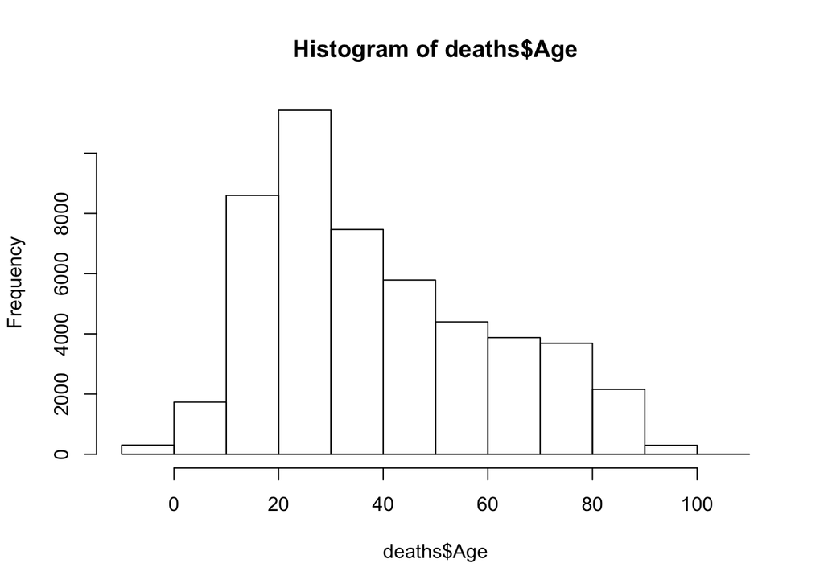

```r
deaths <- read.csv("bitre_ardd_fatalities_dec_2018.csv")
hist(deaths$Age, breaks = c(seq(-10, 110, 10)))
```

In RStudio, try clicking the “Play” button in the top right hand corner of the grey section of code above or the “Run” button at the top right of the panel.

This approach of combining modelling code and commentary is called literate programming.

With this approach, there are several key advantages: * All in R and RStudio – easier to manage single tool * Encourages better documentation * Plain text file format – easier for version control tools such as Git.

It is also worthwhile to note several limitations of this approach:

- Report structure is practically constrained to follow the code - typically data, exploration, models and then results. Producing an executive summary tables and graphs out of order requires workarounds.
- There is a complexity limit for which a single file is practical. For larger projects, it would be typically be best practice to split into multiple R files.

This makes the format quite suited for technical actuarial documents. Conversely, the dashboard format in the next section may be a better format for presenting to business stakeholders.